```python
from IPython.display import HTML

HTML('''<script>
code_show=true;
function code_toggle() {
 if (code_show){
 $('div.input').hide();
 } else {
 $('div.input').show();
 }
 code_show = !code_show
}
$( document ).ready(code_toggle);
</script>
<form action="javascript:code_toggle()"><input type="submit" value="Click here to toggle on/off the raw code."></form>''')
```

```python
# importing packages
%pip install Stargazer
%matplotlib inline
import numpy as np
import pandas as pd
import matplotlib.pyplot as plt
from matplotlib import style
style.use('seaborn-darkgrid')
import seaborn as sns
import statsmodels.formula.api as smf
import statsmodels.stats.api as sms
import scipy.stats
from scipy.stats import norm

from statsmodels.stats.outliers_influence import variance_inflation_factor
from stargazer.stargazer import Stargazer
from IPython.core.display import HTML
from IPython.display import display
```

# Hedonic Pricing in the Gwangju Real Estate Market

### Group 15: Benjamin Bustos, Mandy Cao, Elijah Reisman, Isaac Shon

**Table of Contents**

- I. Introduction/Motivation
- II. Data
- III. Methodology & Empirical Model
- IV. Results
- V. Conclusion
- VI. References

# I. Introduction/Motivation

Although a relatively small and compact nation, South Korea has achieved considerable success in achieving rapid economic growth, poverty reduction, and urbanization in the 70 years following the conclusion of the Korean War. Like the rest of the nation, the City of Gwangju has not diverged from this trend- it has also enjoyed a dramatic economic and cultural transformation. Amongst South Koreans, the city is most well-known for its historic traditions, cultural influence, and participation in demonstration movements during the nation's periods of social and political turmoil. In particular, it has been the center of the nation's most monumental protest movements against Japanese imperialism and pro-democracy uprisings in the 20th century (Gwangju City, n.d.).

Today, the "City of Light" is a thriving, modernized, and densely-populated city with skylines scattered with high-rise apartments. However, of the 6 autonomously-administrated metropolitan cities in South Korea, Gwangju has predominantly been the smallest major city in South Korea (Nations Online, n.d.). The city uniquely stands out in that it is the only major metropolitan area in Korea's Southwest region and serves as the region's heartbeat of economic activity. In the 1950s and 1960s, the two decades following the Korean War, the city's economic growth was much lower than other cities surrounding the capital city of Seoul and other metropolitan areas in the Southeast region. Thus, compared to other major cities, Gwangju has historically struggled in terms of socioeconomic development and urban expansion (Seo, 2013). Given its relative isolation from the nation's capital and other coastal economic hubs, we would like to take an in-depth, exploratory analysis of the housing market in the City of Gwangju. We would like to identify what are the most important internal features of properties in this specific city, and what external/spatial determinants are likely to influence property prices.

This is a question of interest to policymakers, real estate developers, city planning officials, and other stakeholders in the Gwangju housing market. For example, city planners may be interested in finding whether the presence of new public services such as public transportation will have adverse effects on housing affordability. On the other hand, real estate investors and potential homeowners may find useful information on what features affect home values and guide their own investment decisions. We will use Ordinary least squares (OLS) to uncover parameter estimates of how several physical, geographic, and demographic characteristics of properties affect their respective prices. We hope that in doing so, we may yield valuable insights to not only individuals interested in how the housing market works in this urban center, but also to policymakers and actors in the private sector.

**Research question: What factors affect the prices of homes in the City of Gwangju?**

# II. Data

**Background on Dataset**

For this project, we will use will be data collected by Song, Y., Ahn, K.W., & Jang, H.W. (2021) in "Economic impacts of being close to subway networks: A case study of Korean metropolitan areas". The study conducted by Ahn et al. (2021) incorporates data from numerous metropolitian areas in South Korea (e.g., Busan, Daejeon, and Daegu) and places greater emphasis on subway systems and spatial analysis. While the use of shapefiles and GIS environments will be limited in our analysis, we will still attempt to leverage several of the recorded spatial indicators into our own model.

The dataset pertaining to Gwangju comprises of 30 variables on 25,984 condominium prices (the dominant housing type in South Korea) in 2015 sourced from government and official real estate transaction data. These variables speak about the inherent features of home properties, as well as variables regarding geography and local demographic characteristics. We are confident that this dataset will nonetheless allow us to tell a compelling story that elucidates the relationship between a variety of geographic, physical, and demographic indicators through a linear regression model. Below is an image generated in ArcGIS with a shapefile provided by Ahn et al. (2021) of the Gwangju condominiums sampled. As shown in the map produced, the observed condominiums (represented by dots) represent almost all corners of the city and are spread out throughout much of its wards:

*Figure 1. Map of Dataset Observations*

[figure not shown]

**Composition of Original Dataset**

As previously mentioned, we have **30 variables** on **25,984** observations in our dataset. Our primary goal in this project is to determine what key characteristics of a home, as well as what external environmental factors, have the most influence on property prices in Gwangju. While we will not include all 30 variables into our analysis, in this section we will introduce and discuss a specific subset of variables that we believe are the most relevant in determining home prices, re-specify certain variables, and illustrate key patterns in our data.

```python
#Importing the dataset
dataset = pd.read_excel('prices_gwangju.xlsx')
prices_g = pd.DataFrame(dataset.copy())

#Cleaning our dataset to simplify/rename our variables of interest:
prices_g = prices_g.rename({'Size of unit' : 'UnitSize',
                        'Condominium price' : 'PriceCondo',
                        'Floor' : 'Floor',
                        'Construction year' : 'ConYear',
                        'Network distance to nearest subway station' : 'NDSubway',
                        'Parking space per household' : 'PSpaceHouse',
                        'Heating type' : 'TypeHeat',
                        'Number of high schools' : 'HSCount',
                        'Network distance to nearest greenspace' : 'NDGreenspace',
                        'Network distance to nearest waterfront' : 'NDWaterfront',
                        'Number of bus stops' : 'BusStops',
                        'Population' : 'Pop',
                        'Sex ratio' : 'SexRatio',
                        'Medium age' : 'MedAge',
                        'Young population ratio' : 'YPopRatio',
                        'Population density' : 'PopDense'}, axis = 'columns')
```

```python
#Respecifying Population density to reflect number of thousand persons per square kilometer:
prices_g['PopDense']=prices_g['PopDense']/1000

# Respecifying variable to be expressed in kilometers as opposed to meters:
prices_g['NDSubway'] = prices_g['NDSubway']/1000

# Respecifying variables to be expressed in kilometers as opposed to meters:
prices_g['NDGreenspace'] = prices_g['NDGreenspace']/1000
prices_g['NDWaterfront'] = prices_g['NDWaterfront']/1000

prices_g['Age'] = 2022 - prices_g['ConYear']
```

```python
#Creating Season as a categorical variable
season = prices_g[['Spring', 'Fall', 'Winter']]
not_summer_array = season.Spring.astype(int) + season.Fall.astype(int) + season.Winter.astype(int)
season['Summer'] = (not_summer_array == 0)
season['Summer'] = season['Summer'].astype(int)
season = pd.Series(season.columns[np.where(season != 0 )[1]])
prices_g["Season"] = season
```

**Variables of Interest (Renamed)**

[output not shown]

### Understanding the Data

In this section, we present several graphs and visualizations of how the variables in our cross-sectional dataset behave. The plots provided below include how certain variables relate to price, how our demographic variables behave, and how the values of certain variables are distributed. In doing this, we hope to extrapolate useful information that will aid us in building a rich regression model.

We will first look at our dependent variable of interest, the price of the condominium. In our dataset, 'PriceCondo' is expressed in Korean won per square meter (won/m$^2$). But first, we would like to have our dependent variable expressed only in terms of price. This can be achieved if we multiply 'PriceCondo' with 'UnitSize', which is also expressed in square meters.

From the plot below, we find that the distribution of home prices in our dataset is right-skewed. This is a reasonable pattern to observe. In any urban area, homes may typically cost a modest amount, whereas a few number of homes will cost a very large amount. Perhaps this reflects the usual tendency of cities to have a scarce number of "luxury" or "high-value" condominiums.

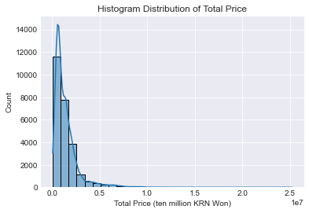

```python
#Condominium prices, expressed in Korean Won:
prices_g["TotalPrice"] = (prices_g["PriceCondo"]*prices_g["UnitSize"])

#Distribution of: Total_Price
g = sns.histplot(x = 'TotalPrice', data = prices_g, bins = 30, kde=True)
g.set(title ="Histogram Distribution of Total Price")
g.set_xlabel("Total Price (ten million KRN Won)")
g.set_ylabel("Count")
```

Upon visual inspection of 'TotalPrice', we find that the variable has a highly right-skewed distribution. We decided to logarithmically transform our dependent variable 'TotalPrice', as this transformation is a convenient method to turn a highly skewed variable into one that is more approximately normal. When we construct our regression model, it may be the case that our regressors do not have unit change effects on condominium prices, but rather percent change effects. By including a logarithmic transformation in our dependent variable, our regression may fit with our data more comprehensively and produce smaller errors.

[output not shown]

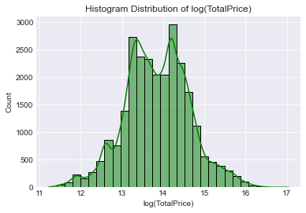

```python
#Applying logarithmic transformation to Total_Price:
prices_g["LTotalPrice"] = np.log(prices_g["TotalPrice"])
2
#Plotting histogram of log-transformed Total_Price:
g = sns.histplot(prices_g['LTotalPrice'], bins = 30, color = 'green', kde=True)
g.set(title ="Histogram Distribution of log(TotalPrice)", xlabel = "log(TotalPrice)", ylabel =  "Count")
```

#### Intrinsic Characteristics

Next, we provide visualizations on the intrinsic traits of homes that we believe have an influence on their price. The first variable we are interested in is the unit size of the property, as we believe that larger spaces in urban areas will more expensive than smaller units. We provide a scatterplot between unit size and log(TotalPrice), and visual inspection of this scatterplot suggests that this relationship is positive.

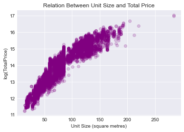

```python
# Scatterplot relating UnitSize and log(TotalPrice):
plt.scatter(x = "UnitSize", y = 'LTotalPrice', data = prices_g, alpha = 0.2, color = 'purple')
plt.title("Relation Between Unit Size and Total Price")
plt.xlabel("Unit Size (square metres)")
plt.ylabel("log(TotalPrice)")
```

We are also interested in whether the age of the property affects price. While we are induced to believe that newly developed condominiums will be more expensive than older units, perhaps the opposite may be true as well. We first provide a barplot of the construction year of each unit in our dataset. We find that newer condominiums are slightly more represented in our dataset than older units. In our dataset, we can see that the vast majority of condominiums were constructed during the 1990s and 2000s. It would be reasonable to observe that more condominiums would have been built in more recent decades. The trend may also reflect the longstanding interest by the central and municipal governments since to revitalize urban growth in Gwangju and "creating regional economic parity in Korea" (Seo, 2013).

```python
# Creating a function that assigns a category based on the construction decade of unit:
def func(x):
    if x < 1980:
        return '1970s'
    elif x >= 1980 and x < 1990:
        return '1980s'
    elif x >= 1990 and x < 2000:
        return '1990s'
    elif x >=2000 and x < 2010:
        return '2000s'
    else:
        return '2010s'

prices_g['ConYearCategory'] = prices_g['ConYear'].apply(func)
```

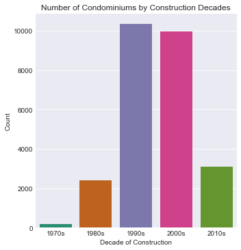

```python
# Count of units based on the construction decade:
g = sns.catplot(x = 'ConYearCategory', kind = 'count', data = prices_g, order = ['1970s','1980s','1990s','2000s','2010s'], palette = "Dark2")
g.set(title = "Number of Condominiums by Construction Decades", xlabel = "Decade of Construction", ylabel = "Count")
```

We also want to delve into whether the type of heating provided by a condominium systematically alters home prices. Below we have provided a bar plot of the type of gas provided on the property for each unit in the dataset. Here, we find that properties that rely on city gas make up are much less represented than properties that use gas from other sources. Of our 25,984 observations, 24,680 units used gas from other sources. While these units find vast representation, we still have 1,304 units that use city gas.

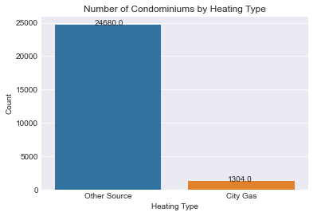

```python
def Heating(x):
    if x == True:
        return "Other Source"
    else:
        return "City Gas"
prices_g['Heat'] = prices_g['TypeHeat'].apply(Heating)

ax = sns.countplot(x = 'Heat', data = prices_g)
ax.set(title = "Number of Condominiums by Heating Type", xlabel = "Heating Type", ylabel = "Count")

for p in ax.patches:
   ax.annotate('{:.1f}'.format(p.get_height()), (p.get_x()+0.3, p.get_height()+0.1))
```

#### Local Demographic Characteristics

Another set of variables, such as local demographic features, are dimensions that may affect people's property preferences. We first look at the ratio of young people in a neighborhood (defined as 100*(# of people younger than 15) ÷ total population) and how this variable affects log(Total_Price).

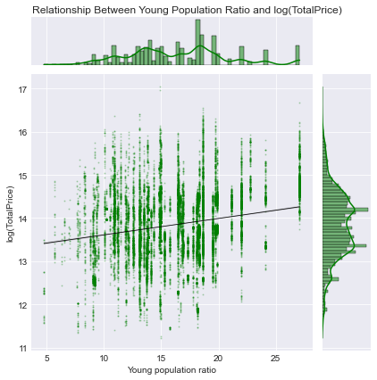

```python
g = sns.jointplot(x = "YPopRatio", y = "LTotalPrice", color = 'green', scatter_kws={'alpha':0.2, 's':1.2}, line_kws={'color': 'black', 'lw':0.75}, data=prices_g, kind='reg')
g.fig.suptitle("Relationship Between Young Population Ratio and log(TotalPrice)")
g.fig.subplots_adjust(top=0.95)
g.set_axis_labels('Young population ratio', 'log(TotalPrice)')
```

Looking at local population densities and how they relate to total price is also another relationship we wanted to visualize and understand. We entertained the idea that areas with dense populations may make properties more expensive. Using a scatter plot, we were able to visualize an upward slope between log(TotalPrice) and population density, which we respecified to be expressed as thousands of people per square kilometer. While it is possible that high density-areas can bring down property valuations (due to the potential for higher pollution, traffic congestion, etc.), evidence of this relationship does not appear to be reflected in our scatterplot. This is most likely due to the fact that the City of Gwangju has a smaller population compared to other major metropolitan cities in South Korea, so the negative externalities associated with population density may not be necessarily present or be reflected in property valuation.

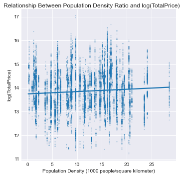

```python
g = sns.lmplot(x = "PopDense", y = "LTotalPrice", scatter_kws={'alpha':0.2, 's':1.2}, data=prices_g)
g.fig.suptitle("Relationship Between Population Density Ratio and log(TotalPrice)")
g.fig.subplots_adjust(top=0.95)
g.set_axis_labels('Population Density (1000 people/square kilometer)', 'log(TotalPrice)')
```

#### Local Amenities

We are well aware that the intrinisic traits of condominiums alone **are not** the sole determinants of home prices. Neighborhoods can vary in their public transportation accessibility, ambient aesthetics, etc. Due to the variation in the geographic characteristics of homes, we expect that local amenities could be another aspect that can affect residency demand and prices.

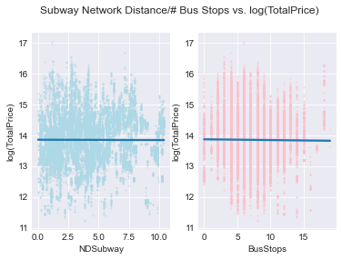

```python
# Creating two scatterplots that reflect how log(Total Price) varies with the presence of subways and number of bus stops:
plt.subplot(1, 2, 1)
sns.regplot(x = "NDSubway", y = 'LTotalPrice', data = prices_g, scatter_kws={'color':'lightblue', 'alpha':0.4, 's':1.2})
plt.ylabel("log(TotalPrice)")

plt.subplot(1, 2, 2)
sns.regplot(x = "BusStops", y = 'LTotalPrice', data = prices_g, scatter_kws={'color':'pink', 'alpha':0.4, 's':1.2})
plt.ylabel("log(TotalPrice)")

plt.suptitle("Subway Network Distance/# Bus Stops vs. log(TotalPrice)")
```

This section also investigates how environmental factors behave in our dataset, as we think that the proximity of open green space and access to open water in an urban cluster may have an effect in property valuation. Below is a set of box-and-whisker plots that shows the network distance of a home to a waterfront (nearest river, stream, pond, or seashore) and greenspace (nearest park, hill, or mountain). Overall, the condominiums in our sample tend to be further away from waterfronts than greenspaces, which can be seen from the fact that the plot for 'NDWaterfront' generally lies higher than 'NDGreenspace'. This is a reasonable trend to observe from our dataset. Gwangju is a landlocked city cushioned within the South Jeolla Province of South Korea, and the only major river crossing through it is the Yeongsan River (see Figure 1). Greenspace, on the other hand, is abundant. While there are several parks and recreation areas scattered throughout the city, Gwangju is also surrounded by small mountains to its east and west. Overall, we find that there is a scarcity of properties within very close proximity (< 250 m) to waterfronts.

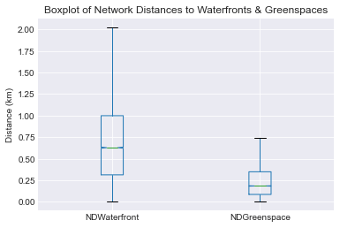

```python
# Creating a boxplot for two variables:
bplot = prices_g.boxplot(column = ["NDWaterfront", "NDGreenspace"], notch = True, showfliers = False)
bplot.plot()
plt.title('Boxplot of Network Distances to Waterfronts & Greenspaces')
plt.ylabel('Distance (km)')
plt.show()
```

#### Seasonality

We took in our 3 seasonal dummy variables and formed a new categorical variable called ‘Season’. Our original dataset only provided dummy variables for ‘Fall’, ‘Spring’, and ‘Winter’. However, we were able to identify whether a given condominium was purchased in the summer by checking if an observation had all three seasonal dummy variables equal to 0. Given our new categorical ‘Season’ variable, we will set our reference category as ‘Fall’ in our subsequent regressions. When we disaggregate our data by ‘Season’, we find that the mean prices of Gwangju condominiums are greatest in Fall of 2015 and smallest in Spring of 2015.

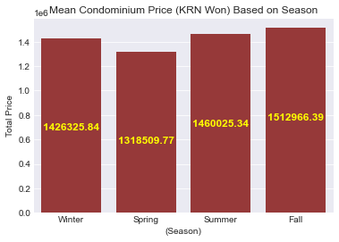

```python
# Creating barplot that takes the average price of condominiums, disaggregated by season:
ax = sns.barplot(x="Season", y="TotalPrice", palette=['brown'], ci=None, data=prices_g)
for p in ax.patches: ax.annotate(np.round(p.get_height(),decimals=2),
                                  (p.get_x()+p.get_width()/2., p.get_height()),
                                   ha='center', va='center', xytext=(0, -100),
                                   textcoords='offset points',color='yellow', fontweight='bold', fontsize=12 )
ax.set(title ="Mean Condominium Price (KRN Won) Based on Season",
        xlabel = "(Season)",
        ylabel =  "Total Price")
plt.show;
```

# III. Methodology & Empirical Model

Before we construct a linear regression model, we would like to identify if any two variables are linked with each other/move in a certain direction with one another. In the correlation matrix presented below, we find that none of our independent variables share a perfect linear correlation with each other.

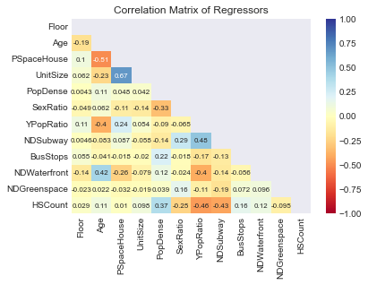

```python
matrixdata = pd.DataFrame({'Floor': prices_g['Floor'],
                          'Age': prices_g['Age'],
                          'PSpaceHouse': prices_g['PSpaceHouse'],
                          'UnitSize':prices_g['UnitSize'],
                          'PopDense':prices_g['PopDense'],
                          'SexRatio':prices_g['SexRatio'],
                          'YPopRatio':prices_g['YPopRatio'],
                          'NDSubway':prices_g['NDSubway'],
                          'BusStops':prices_g['BusStops'],
                          'NDWaterfront':prices_g['NDWaterfront'],
                          'NDGreenspace':prices_g['NDGreenspace'],
                          'HSCount':prices_g['HSCount']})
corr = matrixdata.corr()
matrix = np.triu(corr)
g = sns.heatmap(corr, cmap = 'RdYlBu', annot=True, annot_kws={"size":8}, mask = matrix, vmin=-1, vmax=1)
g.set_title('Correlation Matrix of Regressors')
```

```python
vif = pd.DataFrame()
vif["Variable Names"] = matrixdata.columns
vif["VIF"] = [variance_inflation_factor(matrixdata.values, i) for i in range(matrixdata.shape[1])]

# View results using print
vif=round(vif,3)
display(vif)
```

|  | Variable Names | VIF |
| --- | --- | --- |
| 0 | Floor | 3.655 |
| 1 | Age | 14.486 |
| 2 | PSpaceHouse | 18.394 |
| 3 | UnitSize | 18.889 |
| 4 | PopDense | 5.661 |
| 5 | SexRatio | 81.914 |
| 6 | YPopRatio | 24.714 |
| 7 | NDSubway | 5.252 |
| 8 | BusStops | 6.021 |
| 9 | NDWaterfront | 4.246 |
| 10 | NDGreenspace | 2.341 |
| 11 | HSCount | 12.234 |

### Regression Model

**The Linear Regression Model**

Given the background information and the patterns available in our data set, we find several variables of interest in our data that are most likely to influence condominum prices in Gwangju. We will run multiple regressions that will either confirm or reject our predictions. Then, we will use Ordinary Least Squares (OLS) to extract parameter estimates from different models to gather information about the relationships between our variables, and will test for the significance of those results. Given our preliminary data analysis, we believe that it may not be necessary to apply transformations to our regressors. However, we decided to opt for a log-level model and apply a logarithmic transformation to linearize our dependent variable 'TotalPrice'.

In our first model, we would like to test if any of the variables that relate to the inherent traits of condominiums have a significant effect on their prices via a log-level model:

$$log(TotalPrice) = \beta_0 + \beta_1 Floor + \beta_2 Age + \beta_3 PSpaceHouse + \beta_4 UnitSize + U $$

However, as previously mentioned, we are not solely interested in whether the inherent features of condominiums are determinants of home price. We are also keen in exploring whether demographic characteristics affect property valuations. Our second model gathers these variables:

$$ log(TotalPrice) = \beta_0 + \beta_1 Floor + \beta_2 Age + \beta_3 PSpaceHouse + \beta_4 UnitSize + \beta_5 PopDense + \beta_6 YPopRatio + U $$

We also want to know if local amenity services play any role in condominium valuation, and if so, to what extent. Does the presence of public transportation access make housing *more* or *less* affordable? In our third model, we would like to test if any of the variables related to internal, demographic, and spatial characteristics have any effect on condominium prices.

$$log(TotalPrice) = \beta_0 + \beta_1 Floor + \beta_2 Age + \beta_3 PSpaceHouse + \beta_4 UnitSize + \beta_5 PopDense + \beta_6 YPopRatio + \beta_7 NDSubway + \beta_{8} BusStops + \beta_9 NDWater + \beta_{10} NDGreen + \beta_{11} HSCount + U $$

In our fourth model, we have included a dummy variable to see if the price of condominiums systematically differ depending on the type of heating (i.e., city gas or other sources).

$$log(TotalPrice) = \beta_0 + \beta_1 Floor + \beta_2 Age + \beta_3 PSpaceHouse + \beta_4 UnitSize + \beta_5 PopDense + \beta_6 YPopRatio + \beta_7 NDSubway + \beta_8 BusStops + \beta_9 NDWater + \beta_{10} NDGreen + \beta_{11} HSCount + \beta_{12} TypeHeat + U $$

We will also incorporate the categorical variable 'Season' (with "Fall" being our reference group) to measure seasonality effects in 2015. Our fifth model is described as follows:

$$log(TotalPrice) = \beta_0 + \beta_1 Floor + \beta_2 Age + \beta_3 PSpaceHouse + \beta_4 UnitSize + \beta_5 PopDense + \beta_6 YPopRatio + \beta_7 NDSubway + \beta_{8} BusStops + \beta_9 NDWater + \beta_{10} NDGreen + \beta_{11} HSCount + \beta_{12} TypeHeat + \beta_{13} Season + U $$

**Economic Hypothesis**

| Variable Name | Predicted Direction of Relation with Total Price | Intuition |
| --- | --- | --- |
| UnitSize | Positive | A larger condominium should be more valuable, because more is better when buying a good. |
| Floor | Positive | A higher floor gives condominium owners a better view which increases the condominium value. |
| Age | Negative | An older property is more used, and generally worth less than a newer property. |
| NDSubway | Negative | Easier access to public transportation is an amenity which increases value. |
| NDGreenspace | Negative | Easier access to scenic locations is an amenity which increases value. |
| NDWaterFront | Negative | Easier access to scenic locations is an amenity which increases value. |
| HSCount | Positive | Families are willing to spend more money if educational resources in the area are plentiful. |
| BusStops | Positive | Easier access to public transportation is an amenity which increases value. |
| PopDense | Negative | Crowded areas are less desirable thus decreasing property value. |
| PSpaceHouse | Positive | More parking space should be more valuable, because more is better when buying a good. |
| TypeHeat | Use of City Gas Decreases Total Price | Wealthier people are able to use private gas, and wealthier people are associated with higher property value. |
| YPopRatio | Positive | Higher youth populations are associated with more families, which would increase property value. |

**Testing for Heteroskedasticity**

Before we present our regression results, we are first interested in testing for heteroskedasticity. We would like to see if the variance of the error terms is unrelated to our regressors. If heteroskedasticity is present, this violates the Gauss-Markov assumption in the linear regression model that the variance of the error term is constant (i.e., homoskedastic). While the presence of heteroskedasticity still renders OLS as an unbiased estimator, if we fail to account for this, OLS is no longer the best linear unbiased estimator (BLUE) because the estimated standard errors will be incorrect. If our estimated standard errors are invalid, subsequent hypotheses/inference tests cannot be relied upon. Below, we test for heteroskedasticity by conducting a Breusch-Pagan Test at the 0.05 significance level in our fifth model and find that heteroskedasticity may be present:

```python
# Running Breusch-Pagan Test For Heteroskedasticity
m5 = smf.ols('np.log(TotalPrice) ~ Floor + Age + PSpaceHouse + UnitSize + PopDense + SexRatio + YPopRatio + NDSubway + BusStops + NDWaterfront + NDGreenspace + HSCount + TypeHeat + C(Season)', data = prices_g).fit()
test_m5 = sms.het_breuschpagan(m5.resid, m5.model.exog)
pval_m5 = test_m5[1]

# Null Hypothesis: Homoskedasticity is present
print("Conclusion:")
if pval_m5 >= 0.05:
    print('Homoskedasticity Present')
else:
    print('Heteroskedasticity Present')
```

```
Conclusion:
Heteroskedasticity Present
```

```python
# Running Regressions: Heteroskedasticity-Robust S.E.
# Defining our first three models
m1 = smf.ols('np.log(TotalPrice) ~ Floor + Age + PSpaceHouse + UnitSize', data = prices_g).fit(cov_type='HC0')
m2 = smf.ols('np.log(TotalPrice) ~ Floor + Age + PSpaceHouse + UnitSize + PopDense + SexRatio + YPopRatio', data = prices_g).fit(cov_type='HC0')
m3 = smf.ols('np.log(TotalPrice) ~ Floor + Age + PSpaceHouse + UnitSize + PopDense + SexRatio + YPopRatio + NDSubway + BusStops + NDWaterfront + NDGreenspace + HSCount', data = prices_g).fit(cov_type='HC0')
# The next model adds our dummy variable:
m4 = smf.ols('np.log(TotalPrice) ~ Floor + Age + PSpaceHouse + UnitSize + PopDense + SexRatio + YPopRatio + NDSubway + BusStops + NDWaterfront + NDGreenspace + HSCount + TypeHeat', data = prices_g).fit(cov_type='HC0')
# Fifth model adds Season as a categorical variable:
m5 = smf.ols('np.log(TotalPrice) ~ Floor + Age + PSpaceHouse + UnitSize + PopDense + SexRatio + YPopRatio + NDSubway + BusStops + NDWaterfront + NDGreenspace + HSCount + TypeHeat + C(Season)', data = prices_g).fit(cov_type='HC0')

models = Stargazer([m1, m2, m3, m4, m5])
models.title('Regression on Log(TotalPrice)')
models.covariate_order(['Intercept', 'Floor', 'Age', 'PSpaceHouse', 'UnitSize', 'PopDense', 'SexRatio', 'YPopRatio', 'NDSubway', 'BusStops', 'NDWaterfront', 'NDGreenspace', 'HSCount', 'TypeHeat', 'C(Season)[T.Spring]', 'C(Season)[T.Summer]', 'C(Season)[T.Winter]'])
models.significant_digits(4)
HTML(models.render_html())
```

Regression on Log(TotalPrice)

|  | *Dependent variable:np.log(TotalPrice)* |  |  |  |  |
| --- | --- | --- | --- | --- | --- |
|  | (1) | (2) | (3) | (4) | (5) |
| Intercept | 11.9838*** | 11.8422*** | 11.6443*** | 11.6937*** | 11.7678*** |
|  | (0.0160) | (0.0409) | (0.0474) | (0.0474) | (0.0478) |
| Floor | 0.0072*** | 0.0064*** | 0.0061*** | 0.0061*** | 0.0062*** |
|  | (0.0003) | (0.0003) | (0.0003) | (0.0003) | (0.0003) |
| Age | -0.0130*** | -0.0107*** | -0.0102*** | -0.0102*** | -0.0101*** |
|  | (0.0003) | (0.0003) | (0.0003) | (0.0003) | (0.0003) |
| PSpaceHouse | 0.2831*** | 0.2342*** | 0.2381*** | 0.2397*** | 0.2390*** |
|  | (0.0095) | (0.0092) | (0.0094) | (0.0095) | (0.0095) |
| UnitSize | 0.0252*** | 0.0255*** | 0.0254*** | 0.0254*** | 0.0254*** |
|  | (0.0002) | (0.0002) | (0.0002) | (0.0002) | (0.0002) |
| PopDense |  | 0.0069*** | 0.0057*** | 0.0055*** | 0.0054*** |
|  |  | (0.0003) | (0.0003) | (0.0003) | (0.0003) |
| SexRatio |  | -0.0025*** | -0.0017*** | -0.0018*** | -0.0021*** |
|  |  | (0.0004) | (0.0004) | (0.0004) | (0.0004) |
| YPopRatio |  | 0.0175*** | 0.0213*** | 0.0208*** | 0.0208*** |
|  |  | (0.0004) | (0.0006) | (0.0006) | (0.0006) |
| NDSubway |  |  | -0.0029*** | -0.0027*** | -0.0030*** |
|  |  |  | (0.0008) | (0.0008) | (0.0008) |
| BusStops |  |  | 0.0009* | 0.0013** | 0.0012** |
|  |  |  | (0.0005) | (0.0005) | (0.0005) |
| NDWaterfront |  |  | -0.0004 | -0.0001 | -0.0028 |
|  |  |  | (0.0040) | (0.0040) | (0.0040) |
| NDGreenspace |  |  | 0.0400*** | 0.0357*** | 0.0310*** |
|  |  |  | (0.0068) | (0.0068) | (0.0069) |
| HSCount |  |  | 0.0029*** | 0.0030*** | 0.0028*** |
|  |  |  | (0.0003) | (0.0003) | (0.0003) |
| TypeHeat |  |  |  | -0.0421*** | -0.0401*** |
|  |  |  |  | (0.0071) | (0.0071) |
| C(Season)[T.Spring] |  |  |  |  | -0.0544*** |
|  |  |  |  |  | (0.0046) |
| C(Season)[T.Summer] |  |  |  |  | -0.0108** |
|  |  |  |  |  | (0.0052) |
| C(Season)[T.Winter] |  |  |  |  | -0.0493*** |
|  |  |  |  |  | (0.0045) |
| Observations | 25,984 | 25,984 | 25,984 | 25,984 | 25,984 |
| R<sup>2</sup> | 0.8763 | 0.8877 | 0.8884 | 0.8885 | 0.8894 |
| Adjusted R<sup>2</sup> | 0.8763 | 0.8876 | 0.8884 | 0.8885 | 0.8894 |
| Residual Std. Error | 0.2765 (df=25979) | 0.2635 (df=25976) | 0.2626 (df=25971) | 0.2625 (df=25970) | 0.2615 (df=25967) |
| F Statistic | 17858.5795*** (df=4; 25979) | 11940.5862*** (df=7; 25976) | 7297.9596*** (df=12; 25971) | 6763.6737*** (df=13; 25970) | 5573.1351*** (df=16; 25967) |
| Note: | *p<0.1; **p<0.05; ***p<0.01 |  |  |  |  |

# IV. Results

## Heteroskedasticity

A Breusch-Pagan Test for heteroskedasticity was conducted for our fifth model. Based on our test, we presume that heteroskedasticity is present in our model. With this knowledge, we conducted our tests using the classical version of White's robust varinace-covariance matrix (by Wooldridge). Below, we provide comparisons of two versions of our complete model: one with unadjusted standard errors, and the other with heteroskedasticity-robust standard errors.

**Final Model**

```python
#Creating two renditions of our final model:
Homoskedasticity_model = smf.ols('np.log(TotalPrice) ~ Floor + Age + PSpaceHouse + UnitSize + PopDense + YPopRatio + NDSubway + BusStops + NDGreenspace + HSCount + TypeHeat + C(Season)', data = prices_g).fit()
m6  = smf.ols('np.log(TotalPrice) ~ Floor + Age + PSpaceHouse + UnitSize + PopDense + YPopRatio + NDSubway + BusStops + NDGreenspace + HSCount + TypeHeat + C(Season)', data = prices_g).fit(cov_type='HC0')

#Putting results into stargazer table
models = Stargazer([Homoskedasticity_model, m6])

models.title('Regression on Log(TotalPrice): Unadjusted S.E. vs. Heteroskedasticity-Robust S.E.')
models.custom_columns(['Unadjusted S.E.', 'Adjusted S.E.'] ,[1,1])
models.covariate_order(['Intercept', 'Floor', 'Age', 'PSpaceHouse', 'UnitSize', 'PopDense', 'YPopRatio', 'NDSubway', 'BusStops', 'NDGreenspace', 'HSCount', 'TypeHeat', 'C(Season)[T.Spring]', 'C(Season)[T.Summer]', 'C(Season)[T.Winter]'])
models.significant_digits(4)
HTML(models.render_html())
```

Regression on Log(TotalPrice): Unadjusted S.E. vs. Heteroskedasticity-Robust S.E.

|  | *Dependent variable:np.log(TotalPrice)* |  |
| --- | --- | --- |
|  | Unadjusted S.E. | Adjusted S.E. |
|  | (1) | (2) |
| Intercept | 11.5420*** | 11.5420*** |
|  | (0.0185) | (0.0227) |
| Floor | 0.0062*** | 0.0062*** |
|  | (0.0003) | (0.0003) |
| Age | -0.0101*** | -0.0101*** |
|  | (0.0003) | (0.0003) |
| PSpaceHouse | 0.2398*** | 0.2398*** |
|  | (0.0070) | (0.0094) |
| UnitSize | 0.0254*** | 0.0254*** |
|  | (0.0001) | (0.0002) |
| PopDense | 0.0058*** | 0.0058*** |
|  | (0.0003) | (0.0003) |
| YPopRatio | 0.0216*** | 0.0216*** |
|  | (0.0005) | (0.0006) |
| NDSubway | -0.0045*** | -0.0045*** |
|  | (0.0008) | (0.0008) |
| BusStops | 0.0011** | 0.0011** |
|  | (0.0005) | (0.0005) |
| NDGreenspace | 0.0230*** | 0.0230*** |
|  | (0.0067) | (0.0068) |
| HSCount | 0.0029*** | 0.0029*** |
|  | (0.0003) | (0.0003) |
| TypeHeat | -0.0395*** | -0.0395*** |
|  | (0.0079) | (0.0072) |
| C(Season)[T.Spring] | -0.0526*** | -0.0526*** |
|  | (0.0045) | (0.0045) |
| C(Season)[T.Summer] | -0.0095* | -0.0095* |
|  | (0.0050) | (0.0052) |
| C(Season)[T.Winter] | -0.0479*** | -0.0479*** |
|  | (0.0046) | (0.0045) |
| Observations | 25,984 | 25,984 |
| R<sup>2</sup> | 0.8893 | 0.8893 |
| Adjusted R<sup>2</sup> | 0.8893 | 0.8893 |
| Residual Std. Error | 0.2616 (df=25969) | 0.2616 (df=25969) |
| F Statistic | 14904.2378*** (df=14; 25969) | 6325.1985*** (df=14; 25969) |
| Note: | *p<0.1; **p<0.05; ***p<0.01 |  |

There are observed changes in the standard errors between the final model assuming unadjusted standard errors and the final model using heteroskedasticity-robust standard errors. The table below records the covariates in which standard errors have changed, whether the inclusion of heteroskedasticity-robust standard errors increases or decreases the standard error of a coefficient, and the absolute value of the difference between the standard errors in the two models.

[output not shown]

## Interpretation of Coefficients in Final Model (with Adjusted S.E.'s):

**Condominium Charateristics**

- An increase in the floor of a condominium by 1 yields an increase in total price for a condominium of 0.62% on average, holding other factors fexed. This result is statistically significant at a confidence level of 99%.
- An increase in the age of a condominium by 1 year yields a decrease in total price for a condominium of 1.01% on average, holding other factors fexed. This result is statistically significant at a confidence level of 99%.
- An increase in the parking space of a household by 1 space yields an increase in total price for a condominium of 23.98% on average, holding other factors fexed. This result is statistically significant at a confidence level of 99%.
- An increase in the unit size of a condominium by 1 square meter yields an increase in total price for a condominium by 2.54% on average, holding other factors fexed. This result is statistically significant at a confidence level of 99%.
- The use of non-city gas in a condominium yields a decrease in total price for a condominium by 3.95% on average, holding other factors fexed. This result is statistically significant at a confidence level of 99%.

**Area Charateristics**

- An increase in the number of people per square kilometer by 1000 locally to a condominium yields an increase in total price for a condominium by 0.58% on average, holding other factors fexed. This result is statistically significant at a confidence level of 99%.
- An increase in the ratio of people under the age of 15 to the total population by 1 yields an increase in total price for a condominium by 2.16% on average, holding other factors fexed. This result is statistically significant at a confidence level of 99%.

**Seasonal Effects**

- The condominium purchase happening in the Spring as opposed to in the Fall yields a decrease in total price for a condominium by 5.26% on average, holding other factors fexed. This result is statistically significant at a confidence level of 99%.
- The condominium purchase happening in the Summer as opposed to in the Fall yields a decrease in total price for a condominium by 0.95% on average, holding other factors fexed. This result is statistically significant at a confidence level of 90%.
- The condominium purchase happening in the Winter as opposed to in the Fall yields a decrease in total price for a condominium by 4.79% on average, holding other factors fexed. This result is statistically significant at a confidence level of 99%.

## Inference

### Hypothesis 1.

$H_0$: The Charateristics of a condominium which are Floor Age PSpaceHouse UnitSize and TypeHeat have zero effect on condominium price which is denoted as Log(TotalPrice).

$H_A$: The Charateristics of a condominium which are Floor Age PSpaceHouse UnitSize and TypeHeat affect condominium price which is denoted as Log(TotalPrice).

### Hypothesis 2.

$H_0$: The Charateristics of a condominium's area which are PopDense and YPopRatio have zero effect on condominium price which is denoted as Log(TotalPrice).

$H_A$: The Charateristics of a condominium's area which are PopDense and YPopRatio affect condominium price which is denoted as Log(TotalPrice).

### Hypothesis 3.

$H_0$: The Charateristics of a condominium's distance and access which are NDSubway Bustops NDGreenSpace and HSCount have zero effect on condominium price which is denoted as Log(TotalPrice).

$H_A$: The Charateristics of a condominium's distance and access which are NDSubway Bustops NDGreenSpace and HSCount affect condominium price which is denoted as Log(TotalPrice).

```python
#Created Lists With Names of the restricted variables for each F Test
Condo_Char = ["Floor", 'Age', 'PSpaceHouse', 'UnitSize', 'TypeHeat']

Area_Char = ['PopDense', 'YPopRatio']

Access_Char = ['NDSubway', 'BusStops', 'NDGreenspace', 'HSCount']


#Created Restricted Regressions For Each Hypothesis that will be tested
RR_Condo_Char = smf.ols('np.log(TotalPrice) ~ PopDense + YPopRatio + NDSubway + BusStops + NDGreenspace + HSCount + C(Season)', data = prices_g).fit(cov_type='HC0')

RR_Area_Char = smf.ols('np.log(TotalPrice) ~ Floor + Age + PSpaceHouse + UnitSize + NDSubway + BusStops + NDGreenspace + HSCount + TypeHeat + C(Season)', data = prices_g).fit(cov_type='HC0')

RR_Access_Char = smf.ols('np.log(TotalPrice) ~ Floor + Age + PSpaceHouse + UnitSize + PopDense + YPopRatio + TypeHeat + C(Season)', data = prices_g).fit(cov_type='HC0')


#Creation F Test Statistics
F_test_Condo_Char = ((m6.rsquared - RR_Condo_Char.rsquared)/len(Condo_Char))/((1 - m6.rsquared)/(m6.nobs - 15 - 1))

F_test_Area_Char = ((m6.rsquared - RR_Area_Char.rsquared)/len(Area_Char))/((1 - m6.rsquared)/(m6.nobs - 15 - 1))

F_test_Access_Char = ((m6.rsquared - RR_Access_Char.rsquared)/len(Access_Char))/((1 - m6.rsquared)/(m6.nobs - 15 - 1))
```

```python
#Creating a list of Degrees of Freedom for different F tests

#Getting Critical Values
Crit_Val_Condo_Char = scipy.stats.chi2.ppf(1-.05, df= RR_Condo_Char.df_model)
Crit_Val_Area_Char = scipy.stats.chi2.ppf(1-.05, df= RR_Area_Char.df_model)
Crit_Val_Access_Char = scipy.stats.chi2.ppf(1-.05, df= RR_Access_Char.df_model)

#Testing Hypothesis
if F_test_Condo_Char >= Crit_Val_Condo_Char:
  print('Reject Null Hypothesis 1 in Favor of the Alternative Hypothesis')
else:
  print('Fail to Reject Null Hypothesis 1')

if F_test_Area_Char >= Crit_Val_Area_Char:
  print('Reject Null Hypothesis 2 in Favor of the Alternative Hypothesis')
else:
  print('Fail to Reject Null Hypothesis 2')

if F_test_Access_Char >= Crit_Val_Access_Char:
  print('Reject Null Hypothesis 3 in Favor of the Alternative Hypothesis')
else:
  print('Fail to Reject Null Hypothesis 3')
```

```
Reject Null Hypothesis 1 in Favor of the Alternative Hypothesis
Reject Null Hypothesis 2 in Favor of the Alternative Hypothesis
Reject Null Hypothesis 3 in Favor of the Alternative Hypothesis
```

# V. Conclusion

**Validity Concerns**

The underlying premise of hedonic regression is that goods (properties) are heterogeneous in their attributes, and that their respective prices are a function of these characteristics. Although we attempt to estimate the effect of a variety of characteristics on 2015 property valuations in Gwangju, there are still several shortcomings in our analysis. First, we believe that some characteristics were unobserved in our regression analysis. For example, the number of rooms/bathrooms may very well have an effect on pricing, even when holding other factors fixed. This characteristic may also be correlated with UnitSize, which questions the validity of the zero conditional mean assumption of our error term. Additionally, other features such as property condition, property renovations, local crime rates, and local tax rates, may have been captured in our unobservables. Although data for these traits may be difficult to obtain, in future studies it may be helpful to incorporate them. We nonetheless believe that our models provide a rich variety of key structural, demographic, and local characteristics of properties.

We would also like to highlight the fact that that our model lacks external validity across different geographies and over time. We cannot make any conclusions about how home attributes affect their prices in nearby cities since we do not have a dataset that represents other areas besides Gwangju. Additionally, these observations only represent transactions that took place in 2015, so we cannot draw any conclusion over more extended timeframes.

More importantly, a major concern inherent in many hedonic regression models pertains to *spatial autocorrelation*, which is the correlation of spatial features shared by nearby properties. Basu & Thibodeau (1998) note that property values are spatially autocorrelated for two primary reasons: first, neighborhoods tend to be developed at similar times, so certain structural characteristics such as size and design features may be shared amongst nearby properties. Secondly, residential properties within a neighborhood also share local amenities, such as public transportation access, schools, etc. The basic linear regression model does not account for spatial autocorrelation, which may introduce bias and weaken the validity of estimation results. In their exploration of housing price determinants in Beijing, Xiao et al. (2017) note that the spatial error model, spatial lag model, as well as eigenvector spatial filtering (ESF) regression models as potential methods to account for this effect. In this project, several spatially autocorrelated variables may potentially include (but are not limited to): UnitSize, BusStops, NDSubway, etc. That being said, the proposed alternative models are relatively advanced and have not been used in this project. However, in future studies, perhaps the use of these models may be preferred over the multiple regression model to eliminate spatial autocorrelation effects.

# VI. References

- Basu, S. & Thibodeau, T (1998). Analysis of spatial autocorrelation in house prices. J. Real Estate Financ. Econ., 17, 61–85.
- Gwangju City (n.d.). About Gwangju. https://www.gwangju.go.kr/eng/contentsView.do?pageId=eng10
- Nations Online (n.d.) Administrative Map of South Korea (Republic of Korea). https://www.nationsonline.org/oneworld/map/korea-south-administrative-map.htm
- Song, Y., Ahn, K.W., & Jang, H.W. (2021). Hedonic dataset of the metropolitan housing market – Cases in South Korea, Data in Brief, Volume 35,106877, ISSN 2352-3409, https://doi.org/10.1016/j.dib.2021.106877.
- Seo, J.K. (2013). Gwangju: A Hub City of Asian Culture and high-tech industry, Cities, Volume 31, Pages 563-577, ISSN 0264-2751, https://doi.org/10.1016/j.cities.2012.05.001.
- Xiao, Y. et al. (2017). Exploring Determinants of Housing Prices in Beijing: An Enhanced Hedonic Regression with Open Access POI Data. ISPRS Int. J. Geo-Inf. 2017, 6, 358. https://doi.org/10.3390/ijgi6110358